# Fund Performance Evaluation (1999–2024): AlphaQuant Strategies

```python
import warnings
warnings.filterwarnings('ignore')
```

```python
import os, sys, time, platform
import numpy as np
import pandas as pd
import yfinance as yf
import matplotlib.pyplot as plt
from scipy.optimize import minimize
from sklearn.covariance import LedoitWolf
from statsmodels.api import OLS, add_constant
from tqdm import tqdm
try:
    from pandas_datareader import data as pdr
except Exception:
    pdr = None

plt.rcParams['figure.figsize'] = (10, 4)
plt.rcParams['axes.grid'] = True

TICKERS = ['AAPL','JPM','HON','NOC','MSFT','JNJ','PG','SPY','IWM','QQQ','ACWI','TLT','GLD','VNQ','UUP']
BENCH_TICKER = 'SPY'
START = '1999-01-01'
END = '2024-12-31'

LOOKBACK_MONTHS = 36
W_MAX = 0.25  # allow a bit more concentration for return-seeking
MIN_LIVE_ASSETS = 5
REBAL_N = 1    # 1=monthly, 3=quarterly, 6=semi-annual

# Fees/costs
MGMT_FEE_ANNUAL = 0.02
PERF_FEE_RATE = 0.20  # performance fee on alpha vs SPY (annual)
TRADING_COST_BPS = 15
PERF_FEE_FREQ = 'A'

# Monte Carlo
MC_NUM_SAMPLES = 50000
SEED = 123
np.random.seed(SEED)

OUTDIR = 'outputs'
os.makedirs(OUTDIR, exist_ok=True)
```

```python
CAP_ASSET_MAX = {'UUP': 0.05, 'TLT': 0.05, 'GLD': 0.05}
DEFAULT_W_MAX = W_MAX  # keep global cap for others
```

```python
def ann_ret_fn(returns, periods=12):
    r = (1 + returns).prod(); n = len(returns)
    if n == 0: return np.nan
    return r**(periods/n) - 1
def ann_vol_fn(returns, periods=12):
    return returns.std(ddof=0) * np.sqrt(periods)
def sharpe_fn(returns, rf=0.0, periods=12):
    ex = returns - rf/periods; vol = ann_vol_fn(ex, periods)
    if vol == 0 or np.isnan(vol): return np.nan
    return ann_ret_fn(ex, periods) / vol
def max_drawdown(equity):
    cummax = equity.cummax(); dd = equity / cummax - 1.0
    return dd.min(), dd
def alpha_beta(port_rets, bench_rets):
    df = pd.concat([port_rets, bench_rets], axis=1).dropna()
    if df.shape[0] < 3: return np.nan, np.nan
    y = df.iloc[:,0]; X = add_constant(df.iloc[:,1])
    model = OLS(y, X).fit(); alpha_m = model.params['const']; beta = model.params.iloc[1]
    return (1+alpha_m)**12 - 1, beta
def apply_mgmt_fee(monthly_ret, mgmt_fee_annual=0.02):
    fee_m = mgmt_fee_annual/12; return (1+monthly_ret)*(1 - fee_m) - 1
def trading_cost(turnover, cost_bps=15):
    return (turnover * (2*cost_bps/10000.0))
def perf_fee_alpha(alpha_monthly, rate=0.20, freq='A'):
    alpha_df = alpha_monthly.to_frame('alpha')
    iterator = (g for _, g in alpha_df.groupby(alpha_df.index.year)) if freq=='A' else [alpha_df]
    out = []
    for grp in iterator:
        cum_alpha = (1+grp['alpha']).prod() - 1
        tmp = grp.copy()
        if cum_alpha > 0:
            fee = rate * cum_alpha; end = grp.index[-1]
            tmp.loc[end, 'alpha'] = (1+tmp.loc[end, 'alpha'])*(1 - fee) - 1
        out.append(tmp['alpha'])
    return pd.concat(out).sort_index()
```

```python
from numpy.linalg import LinAlgError

def est_mu_cov(ret_window):
    mu = ret_window.mean()
    if ret_window.shape[0] >= ret_window.shape[1] + 2:
        try:
            lw = LedoitWolf().fit(ret_window.fillna(0.0).values)
            cov = pd.DataFrame(lw.covariance_, index=ret_window.columns, columns=ret_window.columns)
        except Exception:
            cov = ret_window.cov()
    else:
        cov = ret_window.cov()
    return mu, cov

def align_mu_cov(mu, cov, assets):
    mu = pd.Series(mu).reindex(assets)
    cov = pd.DataFrame(cov, index=cov.index, columns=cov.columns)
    cov = cov.reindex(index=assets, columns=assets)
    mu = mu.fillna(mu.mean()).astype(float)
    cov = cov.fillna(0.0).astype(float)
    return mu, cov

def compute_signals(monthly_px, date):
    mom = (monthly_px / monthly_px.shift(12)) - 1; mom = mom.shift(1)
    ma6 = monthly_px.rolling(6).mean(); mr = (monthly_px - ma6) / monthly_px.rolling(6).std(); mr = -mr
    return mom.loc[date], mr.loc[date]

def solve_max_sharpe(mu, cov, wmax=0.25, bounds=None):
    n = len(mu); mu = np.asarray(mu); cov = np.asarray(cov)
    if bounds is None:
        bounds = [(0.0, wmax)] * n
    x0 = np.ones(n) / n
    cons = ({'type':'eq', 'fun': lambda w: np.sum(w) - 1.0},)
    def neg_sharpe(w):
        ret = w @ mu
        vol = np.sqrt(max(1e-12, w @ cov @ w))
        return -(ret / vol)
    res = minimize(neg_sharpe, x0, method='SLSQP', bounds=bounds, constraints=cons)
    return res.x if res.success else x0

def solve_min_var(cov, wmax=0.25, bounds=None):
    cov = np.asarray(cov); n = cov.shape[0]
    if bounds is None:
        bounds = [(0.0, wmax)] * n
    x0 = np.ones(n) / n
    cons = ({'type':'eq', 'fun': lambda w: np.sum(w) - 1.0},)
    def var(w): return w @ cov @ w
    res = minimize(var, x0, method='SLSQP', bounds=bounds, constraints=cons)
    return res.x if res.success else x0

def solve_inv_vol(cov, wmax=0.25, bounds=None):
    cov = np.asarray(cov); sigma = np.sqrt(np.clip(np.diag(cov), 1e-12, None))
    w = 1.0 / sigma
    w = np.clip(w, 0, None)
    w = w / w.sum()

    if bounds is not None:
        caps = np.array([b[1] for b in bounds])
    else:
        caps = np.full_like(w, wmax, dtype=float)
    w = np.minimum(w, caps)
    s = w.sum()
    if s == 0:  # fallback
        w = np.ones_like(w) / len(w)
    else:
        w = w / s
    return w

def solve_max_return(mu, wmax=0.25, bounds=None):
    mu = np.asarray(mu); n = len(mu)
    if bounds is None:
        bounds = [(0.0, wmax)] * n
    x0 = np.ones(n) / n
    cons = ({'type':'eq','fun': lambda w: np.sum(w) - 1.0},)
    def neg_ret(w): return -(w @ mu)
    res = minimize(neg_ret, x0, method='SLSQP', bounds=bounds, constraints=cons)
    return res.x if res.success else x0
```

```python
data = yf.download(TICKERS, start=START, end=END, auto_adjust=True, progress=False)['Close']
data = data.dropna(how='all')
monthly_px = data.resample('M').last()
monthly_ret = monthly_px.pct_change().dropna(how='all')
first_live = monthly_px.apply(lambda s: s.first_valid_index())
avail = pd.DataFrame(False, index=monthly_px.index, columns=monthly_px.columns)
for col in monthly_px.columns:
    if pd.isna(first_live[col]): continue
    avail.loc[first_live[col]:, col] = True
bench_ret = monthly_ret[BENCH_TICKER].rename('BENCH').dropna()
```

## Asset Summary Table

```python
rows = []
for asset in monthly_px.columns:
    px = monthly_px[asset].dropna()
    if len(px) < 2: continue
    start = px.index[0]; end = px.index[-1]
    years = (end - start).days/365.25
    rets_m = px.pct_change().dropna()
    cagr = (1+rets_m).prod()**(12/len(rets_m)) - 1
    ann_mu = rets_m.mean()*12
    ann_vol = rets_m.std(ddof=0)*np.sqrt(12)
    rows.append(dict(Asset=asset, Start=start.date(), End=end.date(), Years=years, CAGR=cagr, AnnMu=ann_mu, AnnVol=ann_vol))
asset_table = pd.DataFrame(rows).set_index('Asset').reindex(TICKERS)[['Start','End','Years','CAGR','AnnMu','AnnVol']]
asset_table.to_csv(f'{OUTDIR}/asset_summary_table.csv')
asset_table
```

| Asset | Start | End | Years | CAGR | AnnMu | AnnVol |
| --- | --- | --- | --- | --- | --- | --- |
| AAPL | 1999-01-31 | 2024-12-31 | 25.916496 | 0.295049 | 0.340858 | 0.387864 |
| JPM | 1999-01-31 | 2024-12-31 | 25.916496 | 0.092039 | 0.133360 | 0.298114 |
| HON | 1999-01-31 | 2024-12-31 | 25.916496 | 0.096247 | 0.132855 | 0.281983 |
| NOC | 1999-01-31 | 2024-12-31 | 25.916496 | 0.141955 | 0.159980 | 0.230665 |
| MSFT | 1999-01-31 | 2024-12-31 | 25.916496 | 0.112319 | 0.146783 | 0.283823 |
| JNJ | 1999-01-31 | 2024-12-31 | 25.916496 | 0.074961 | 0.086930 | 0.169860 |
| PG | 1999-01-31 | 2024-12-31 | 25.916496 | 0.079001 | 0.092970 | 0.178381 |
| SPY | 1999-01-31 | 2024-12-31 | 25.916496 | 0.079764 | 0.088627 | 0.151864 |
| IWM | 2000-05-31 | 2024-12-31 | 24.585900 | 0.078487 | 0.096500 | 0.202168 |
| QQQ | 1999-03-31 | 2024-12-31 | 25.754962 | 0.099774 | 0.123513 | 0.234674 |
| ACWI | 2008-03-31 | 2024-12-31 | 16.752909 | 0.073894 | 0.086079 | 0.169484 |
| TLT | 2002-07-31 | 2024-12-31 | 22.420260 | 0.037157 | 0.045833 | 0.136974 |
| GLD | 2004-11-30 | 2024-12-31 | 20.084873 | 0.086922 | 0.097425 | 0.166598 |
| VNQ | 2004-09-30 | 2024-12-31 | 20.251882 | 0.073948 | 0.096694 | 0.220414 |
| UUP | 2007-03-31 | 2024-12-31 | 17.754962 | 0.018655 | 0.021506 | 0.077717 |

## EDA

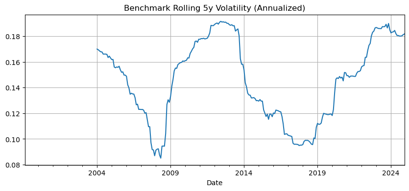

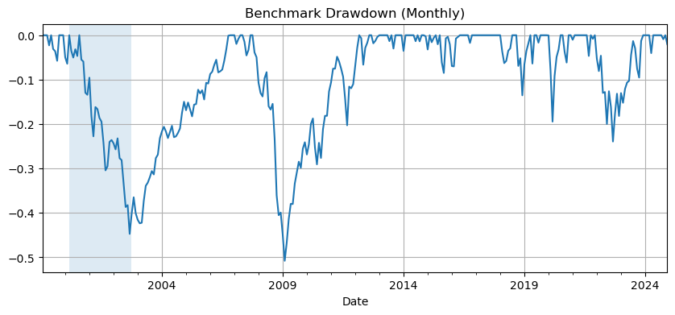

```python
roll_vol = bench_ret.rolling(60).std()*np.sqrt(12)
bench_eq = (1+bench_ret).cumprod(); _, bench_dd = max_drawdown(bench_eq)
fig, ax = plt.subplots(); roll_vol.plot(ax=ax); ax.set_title('Benchmark Rolling 5y Volatility (Annualized)'); plt.show()
fig, ax = plt.subplots(); bench_dd.plot(ax=ax); ax.set_title('Benchmark Drawdown (Monthly)');
for a,b in [(pd.Timestamp('2000-03-01'), pd.Timestamp('2002-10-31')), (pd.Timestamp('2007-10-01'), pd.Timestamp('2009-03-31')), (pd.Timestamp('2020-02-01'), pd.Timestamp('2020-04-30')), (pd.Timestamp('2022-01-01'), pd.Timestamp('2022-10-31'))]: ax.axvspan(a,b,alpha=0.15); plt.show()
```

## Backtest Engine (Dynamic Universe, REBAL_N)

```python
def compute_weights_for_window(ret_win, date_prev, monthly_px, method='max_sharpe', wmax=W_MAX, asset_caps=None):
    assets = list(ret_win.columns)
    mu_base, cov_base = est_mu_cov(ret_win[assets])
    mu_base, cov_base = align_mu_cov(mu_base, cov_base, assets)
    # Momentum + mean reversion tilt
    mom_sig, mr_sig = compute_signals(monthly_px, date_prev)
    mom_sig = mom_sig.reindex(assets).rank(pct=True)
    mr_sig = mr_sig.reindex(assets).rank(pct=True)
    tilt = 0.5 * mom_sig + 0.5 * mr_sig
    mu_tilt = 0.5 * mu_base + 0.5 * (tilt * mu_base.mean())
    mu_tilt = mu_tilt.fillna(mu_base.mean()).astype(float)
    # Build per-asset bounds
    bounds = []
    for a in assets:
        cap = wmax
        if asset_caps and a in asset_caps:
            cap = float(asset_caps[a])
        bounds.append((0.0, cap))
    # Solve
    if method == 'max_sharpe':
        w_vec = solve_max_sharpe(mu_tilt.values, cov_base.values, wmax=wmax, bounds=bounds)
    elif method == 'min_var':
        w_vec = solve_min_var(cov_base.values, wmax=wmax, bounds=bounds)
    elif method == 'risk_parity':
        w_vec = solve_inv_vol(cov_base.values, wmax=wmax, bounds=bounds)
    elif method == 'max_return':
        w_vec = solve_max_return(mu_tilt.values, wmax=wmax, bounds=bounds)
    else:
        raise ValueError('Unknown method')
    w_star = pd.Series(0.0, index=monthly_ret.columns)
    w_star.loc[assets] = w_vec
    return w_star
```

```python
# Caps for low-return diversifiers
CAP_ASSET_MAX = {'UUP': 0.05, 'TLT': 0.05, 'GLD': 0.05}

from numpy.linalg import LinAlgError

def est_mu_cov(ret_window):
    mu = ret_window.mean()
    if ret_window.shape[0] >= ret_window.shape[1] + 2:
        try:
            lw = LedoitWolf().fit(ret_window.fillna(0.0).values)
            cov = pd.DataFrame(lw.covariance_, index=ret_window.columns, columns=ret_window.columns)
        except Exception:
            cov = ret_window.cov()
    else:
        cov = ret_window.cov()
    return mu, cov

def align_mu_cov(mu, cov, assets):
    mu = pd.Series(mu).reindex(assets)
    cov = pd.DataFrame(cov, index=cov.index, columns=cov.columns)
    cov = cov.reindex(index=assets, columns=assets)
    mu = mu.fillna(mu.mean()).astype(float)
    cov = cov.fillna(0.0).astype(float)
    return mu, cov

def compute_signals(monthly_px, date):
    mom = (monthly_px / monthly_px.shift(12)) - 1; mom = mom.shift(1)
    ma6 = monthly_px.rolling(6).mean(); mr = (monthly_px - ma6) / monthly_px.rolling(6).std(); mr = -mr
    return mom.loc[date], mr.loc[date]

# --- Optimizers with per-asset bounds ---
def _build_bounds(assets, wmax, asset_caps=None):
    bounds = []
    for a in assets:
        cap = wmax
        if asset_caps and a in asset_caps:
            cap = float(asset_caps[a])
        bounds.append((0.0, cap))
    return bounds

def solve_max_sharpe(mu, cov, wmax=0.25, bounds=None):
    mu = np.asarray(mu); cov = np.asarray(cov)
    n = len(mu)
    if bounds is None: bounds = [(0.0, wmax)]*n
    x0 = np.ones(n)/n
    cons = ({'type':'eq','fun': lambda w: np.sum(w)-1.0},)
    def neg_sharpe(w):
        ret = w @ mu
        vol = np.sqrt(max(1e-12, w @ cov @ w))
        return -(ret/vol)
    res = minimize(neg_sharpe, x0, method='SLSQP', bounds=bounds, constraints=cons)
    return res.x if res.success else x0

def solve_min_var(cov, wmax=0.25, bounds=None):
    cov = np.asarray(cov); n = cov.shape[0]
    if bounds is None: bounds = [(0.0, wmax)]*n
    x0 = np.ones(n)/n
    cons = ({'type':'eq','fun': lambda w: np.sum(w)-1.0},)
    def var(w): return w @ cov @ w
    res = minimize(var, x0, method='SLSQP', bounds=bounds, constraints=cons)
    return res.x if res.success else x0

def solve_inv_vol(cov, wmax=0.25, bounds=None):
    cov = np.asarray(cov)
    sigma = np.sqrt(np.clip(np.diag(cov), 1e-12, None))
    w = 1.0/sigma; w = np.clip(w, 0, None); w = w / w.sum()
    # apply caps from bounds if provided
    if bounds is not None:
        caps = np.array([b[1] for b in bounds])
    else:
        caps = np.full_like(w, wmax, dtype=float)
    w = np.minimum(w, caps)
    s = w.sum()
    if s == 0: w = np.ones_like(w)/len(w)
    else: w = w/s
    return w

def solve_max_return(mu, wmax=0.25, bounds=None):
    mu = np.asarray(mu); n = len(mu)
    if bounds is None: bounds = [(0.0, wmax)]*n
    x0 = np.ones(n)/n
    cons = ({'type':'eq','fun': lambda w: np.sum(w)-1.0},)
    def neg_ret(w): return -(w @ mu)
    res = minimize(neg_ret, x0, method='SLSQP', bounds=bounds, constraints=cons)
    return res.x if res.success else x0

def compute_weights_for_window(ret_win, date_prev, monthly_px, method='max_sharpe', wmax=W_MAX, asset_caps=None):
    assets = list(ret_win.columns)
    mu_base, cov_base = est_mu_cov(ret_win[assets])
    mu_base, cov_base = align_mu_cov(mu_base, cov_base, assets)
    # simple momentum + mean-reversion tilt
    mom_sig, mr_sig = compute_signals(monthly_px, date_prev)
    mom_sig = mom_sig.reindex(assets).rank(pct=True)
    mr_sig = mr_sig.reindex(assets).rank(pct=True)
    tilt = 0.5*mom_sig + 0.5*mr_sig
    mu_tilt = 0.5*mu_base + 0.5*(tilt * mu_base.mean())
    mu_tilt = mu_tilt.fillna(mu_base.mean()).astype(float)
    bounds = _build_bounds(assets, wmax, asset_caps)
    if method == 'max_sharpe':
        w_vec = solve_max_sharpe(mu_tilt.values, cov_base.values, wmax=wmax, bounds=bounds)
    elif method == 'min_var':
        w_vec = solve_min_var(cov_base.values, wmax=wmax, bounds=bounds)
    elif method == 'risk_parity':
        w_vec = solve_inv_vol(cov_base.values, wmax=wmax, bounds=bounds)
    elif method == 'max_return':
        w_vec = solve_max_return(mu_tilt.values, wmax=wmax, bounds=bounds)
    else:
        raise ValueError('Unknown method')
    w_star = pd.Series(0.0, index=monthly_ret.columns); w_star.loc[assets] = w_vec
    return w_star

def run_backtest(method='max_sharpe', lookback=LOOKBACK_MONTHS, w_cap=W_MAX, mgmt_fee=MGMT_FEE_ANNUAL,
                 perf_fee=PERF_FEE_RATE, tc_bps=TRADING_COST_BPS, reb_n=REBAL_N, asset_caps=None):
    dates = monthly_ret.index; start_idx = lookback + 1
    weights_hist, port_g, port_n, turns = [], [], [], []
    w_prev = None
    for i in tqdm(range(start_idx, len(dates))):
        t = dates[i]; t_prev = dates[i-1]
        live_assets = avail.loc[t_prev]; live_assets = live_assets[live_assets].index.tolist()
        do_rebal = ((i - start_idx) % max(1, reb_n) == 0)
        if do_rebal and len(live_assets) >= MIN_LIVE_ASSETS:
            window_end = t_prev; window_start = dates[i - lookback - 1]
            ret_win = monthly_ret.loc[window_start:window_end, live_assets]
            valid_cols = ret_win.columns[ret_win.notna().sum() >= max(24, lookback//2)]
            ret_win = ret_win[valid_cols].dropna(how='any')
            if ret_win.shape[1] < MIN_LIVE_ASSETS or ret_win.shape[0] < max(12, lookback//2):
                w_star = pd.Series(0.0, index=monthly_ret.columns); w_star.loc[live_assets] = 1.0/max(1, len(live_assets))
            else:
                w_star = compute_weights_for_window(ret_win, t_prev, monthly_px, method=method, wmax=w_cap, asset_caps=asset_caps)
            if w_prev is None: to = np.nansum(np.abs(w_star.values)) * 0.5
            else:
                w_prev = w_prev.reindex(monthly_ret.columns).fillna(0.0); to = 0.5 * np.abs(w_star - w_prev).sum()
            w_prev = w_star.copy(); weights_hist.append((t_prev, w_star)); tc = trading_cost(to, tc_bps)
        else:
            if w_prev is None: w_prev = pd.Series(0.0, index=monthly_ret.columns)
            weights_hist.append((t_prev, w_prev)); tc = 0.0; to = 0.0
        r_t = monthly_ret.loc[t, w_prev.index].fillna(0.0); rg = float(np.dot(w_prev.values, r_t.values)); rn = apply_mgmt_fee(rg, mgmt_fee) - tc
        port_g.append((t, rg)); port_n.append((t, rn)); turns.append((t, to))
    port_g = pd.Series(dict(port_g)).sort_index().rename(f'{method.upper()}_GROSS')
    port_net_pre_pf = pd.Series(dict(port_n)).sort_index().rename(f'{method.upper()}_NET_PRE_PF')
    bn = bench_ret.reindex_like(port_net_pre_pf).dropna(); pn = port_net_pre_pf.reindex(bn.index).dropna()
    alpha_monthly = pn - bn; alpha_after_fee = perf_fee_alpha(alpha_monthly, rate=perf_fee, freq='A')
    port_net = (bn.add(alpha_after_fee, fill_value=0.0)).rename(f'{method.upper()}_NET')
    W = pd.DataFrame({d: w for d, w in weights_hist}).T; W.index = pd.to_datetime(W.index); W = W.sort_index()
    return dict(port_gross=port_g, port_net=port_net, port_net_pre_pf=port_net_pre_pf, weights=W)
```

```python
# Caps for low-return diversifiers (1% max each)
CAP_ASSET_MAX = {'UUP': 0.01, 'TLT': 0.01, 'GLD': 0.01}
MIN_W_DEFAULT = 0.005   # 0.5% for most assets
MIN_W_ASSET = {'UUP': 0.001, 'TLT': 0.001, 'GLD': 0.001}  # 0.1% for capped trio

from numpy.linalg import LinAlgError

def est_mu_cov(ret_window):
    mu = ret_window.mean()
    if ret_window.shape[0] >= ret_window.shape[1] + 2:
        try:
            lw = LedoitWolf().fit(ret_window.fillna(0.0).values)
            cov = pd.DataFrame(lw.covariance_, index=ret_window.columns, columns=ret_window.columns)
        except Exception:
            cov = ret_window.cov()
    else:
        cov = ret_window.cov()
    return mu, cov

def align_mu_cov(mu, cov, assets):
    mu = pd.Series(mu).reindex(assets)
    cov = pd.DataFrame(cov, index=cov.index, columns=cov.columns)
    cov = cov.reindex(index=assets, columns=assets)
    mu = mu.fillna(mu.mean()).astype(float)
    cov = cov.fillna(0.0).astype(float)
    return mu, cov

def compute_signals(monthly_px, date):
    mom = (monthly_px / monthly_px.shift(12)) - 1
    mom = mom.shift(1)
    ma6 = monthly_px.rolling(6).mean()
    mr = (monthly_px - ma6) / monthly_px.rolling(6).std()
    mr = -mr
    return mom.loc[date], mr.loc[date]

def _bounds_with_caps_floors(assets, wmax, asset_caps=None, min_default=0.0, min_asset=None):
    bounds = []
    total_min = 0.0
    for a in assets:
        cap = wmax
        if asset_caps and a in asset_caps:
            cap = float(asset_caps[a])
        mn = min_default
        if min_asset and a in min_asset:
            mn = float(min_asset[a])
        if mn > cap:
            mn = max(0.0, cap - 1e-6)
        bounds.append((mn, cap))
        total_min += mn
    if total_min > 1.0:
        scale = 1.0 / total_min
        bounds = [(mn*scale, mx) for (mn, mx) in bounds]
    return bounds

def solve_max_sharpe(mu, cov, wmax=0.25, bounds=None):
    import numpy as _np
    from scipy.optimize import minimize as _minimize
    mu = _np.asarray(mu)
    cov = _np.asarray(cov)
    n = len(mu)
    if bounds is None: bounds = [(0.0, wmax)]*n
    lb = _np.array([b[0] for b in bounds])
    ub = _np.array([b[1] for b in bounds])
    x0 = lb + 0.5*(ub-lb)
    x0 = x0 / x0.sum()
    cons = ({'type':'eq','fun': lambda w: _np.sum(w)-1.0},)
    def neg_sharpe(w):
        ret = w @ mu
        vol = _np.sqrt(max(1e-12, w @ cov @ w))
        return -(ret/vol)
    res = _minimize(neg_sharpe, x0, method='SLSQP', bounds=bounds, constraints=cons)
    return res.x if res.success else x0

def solve_min_var(cov, wmax=0.25, bounds=None):
    import numpy as _np
    from scipy.optimize import minimize as _minimize
    cov = _np.asarray(cov)
    n = cov.shape[0]
    if bounds is None: bounds = [(0.0, wmax)]*n
    lb = _np.array([b[0] for b in bounds]); ub = _np.array([b[1] for b in bounds])
    x0 = lb + 0.5*(ub-lb); x0 = x0 / x0.sum()
    cons = ({'type':'eq','fun': lambda w: _np.sum(w)-1.0},)
    def var(w):
        return w @ cov @ w
    res = _minimize(var, x0, method='SLSQP', bounds=bounds, constraints=cons)
    return res.x if res.success else x0

def solve_inv_vol(cov, wmax=0.25, bounds=None):
    import numpy as _np
    cov = _np.asarray(cov)
    sigma = _np.sqrt(_np.clip(_np.diag(cov), 1e-12, None))
    w = 1.0/sigma
    w = _np.clip(w, 0, None)
    w = w / w.sum()
    if bounds is not None:
        lb = _np.array([b[0] for b in bounds])
        ub = _np.array([b[1] for b in bounds])
        w = _np.maximum(lb, _np.minimum(w, ub))
        s = w.sum()
        w = w if s == 0 else w / s
    return w

def solve_max_return(mu, wmax=0.25, bounds=None):
    import numpy as _np
    from scipy.optimize import minimize as _minimize
    mu = _np.asarray(mu)
    n = len(mu)
    if bounds is None: bounds = [(0.0, wmax)]*n
    lb = _np.array([b[0] for b in bounds]); ub = _np.array([b[1] for b in bounds])
    x0 = lb + 0.5*(ub-lb); x0 = x0 / x0.sum()
    cons = ({'type':'eq','fun': lambda w: _np.sum(w)-1.0},)
    def neg_ret(w): return -(w @ mu)
    res = _minimize(neg_ret, x0, method='SLSQP', bounds=bounds, constraints=cons)
    return res.x if res.success else x0

def compute_weights_for_window(ret_win, date_prev, monthly_px, method='max_sharpe', wmax=W_MAX, asset_caps=None):
    assets = list(ret_win.columns)
    mu_base, cov_base = est_mu_cov(ret_win[assets])
    mu_base, cov_base = align_mu_cov(mu_base, cov_base, assets)
    mom_sig, mr_sig = compute_signals(monthly_px, date_prev)
    mom_sig = mom_sig.reindex(assets).rank(pct=True)
    mr_sig = mr_sig.reindex(assets).rank(pct=True)
    tilt = 0.5*mom_sig + 0.5*mr_sig
    mu_tilt = 0.5*mu_base + 0.5*(tilt * mu_base.mean())
    mu_tilt = mu_tilt.fillna(mu_base.mean()).astype(float)
    bounds = _bounds_with_caps_floors(assets, wmax, asset_caps=asset_caps,
                                      min_default=MIN_W_DEFAULT, min_asset=MIN_W_ASSET)
    if method == 'max_sharpe':
        w_vec = solve_max_sharpe(mu_tilt.values, cov_base.values, wmax=wmax, bounds=bounds)
    elif method == 'min_var':
        w_vec = solve_min_var(cov_base.values, wmax=wmax, bounds=bounds)
    elif method == 'risk_parity':
        w_vec = solve_inv_vol(cov_base.values, wmax=wmax, bounds=bounds)
    elif method == 'max_return':
        w_vec = solve_max_return(mu_tilt.values, wmax=wmax, bounds=bounds)
    else:
        raise ValueError('Unknown method')
    w_star = pd.Series(0.0, index=monthly_ret.columns)
    w_star.loc[assets] = w_vec
    return w_star

def run_backtest(method='max_sharpe', lookback=LOOKBACK_MONTHS, w_cap=W_MAX, mgmt_fee=MGMT_FEE_ANNUAL,
                 perf_fee=PERF_FEE_RATE, tc_bps=TRADING_COST_BPS, reb_n=REBAL_N, asset_caps=None):
    dates = monthly_ret.index
    start_idx = lookback + 1
    weights_hist, port_g, port_n = [], [], []
    w_prev = None
    for i in tqdm(range(start_idx, len(dates))):
        t = dates[i]; t_prev = dates[i-1]
        live_assets = avail.loc[t_prev]
        live_assets = live_assets[live_assets].index.tolist()
        do_rebal = ((i - start_idx) % max(1, reb_n) == 0)
        if do_rebal and len(live_assets) >= MIN_LIVE_ASSETS:
            window_end = t_prev; window_start = dates[i - lookback - 1]
            ret_win = monthly_ret.loc[window_start:window_end, live_assets]
            valid_cols = ret_win.columns[ret_win.notna().sum() >= max(24, lookback//2)]
            ret_win = ret_win[valid_cols].dropna(how='any')
            if ret_win.shape[1] < MIN_LIVE_ASSETS or ret_win.shape[0] < max(12, lookback//2):
                # Feasible fallback: use floors and then distribute leftover to room up to caps
                assets = live_assets
                bounds = _bounds_with_caps_floors(assets, w_cap, asset_caps=asset_caps,
                                                  min_default=MIN_W_DEFAULT, min_asset=MIN_W_ASSET)
                import numpy as _np
                lb = _np.array([b[0] for b in bounds]); ub = _np.array([b[1] for b in bounds])
                remaining = 1.0 - lb.sum()
                room = ub - lb
                if remaining > 1e-8 and room.sum() > 0:
                    add = room * (remaining / room.sum())
                    w_alloc = lb + add
                else:
                    s = max(lb.sum(), 1.0)
                    w_alloc = lb / s
                w_star = pd.Series(0.0, index=monthly_ret.columns); w_star.loc[assets] = w_alloc
            else:
                w_star = compute_weights_for_window(ret_win, t_prev, monthly_px, method=method, wmax=w_cap, asset_caps=asset_caps)
            import numpy as _np
            if w_prev is None:
                to = _np.nansum(_np.abs(w_star.values)) * 0.5
            else:
                w_prev = w_prev.reindex(monthly_ret.columns).fillna(0.0)
                to = 0.5 * _np.abs(w_star - w_prev).sum()
            w_prev = w_star.copy()
            weights_hist.append((t_prev, w_star))
            tc = trading_cost(to, tc_bps)
        else:
            if w_prev is None:
                w_prev = pd.Series(0.0, index=monthly_ret.columns)
            weights_hist.append((t_prev, w_prev))
            tc = 0.0
        r_t = monthly_ret.loc[t, w_prev.index].fillna(0.0)
        rg = float((w_prev.values * r_t.values).sum())
        rn = apply_mgmt_fee(rg, mgmt_fee) - tc
        port_g.append((t, rg)); port_n.append((t, rn))
    port_g = pd.Series(dict(port_g)).sort_index().rename(f'{method.upper()}_GROSS')
    port_net_pre_pf = pd.Series(dict(port_n)).sort_index().rename(f'{method. upper()}_NET_PRE_PF'.replace(' ',''))

    bn = bench_ret.reindex_like(port_net_pre_pf).dropna()
    pn = port_net_pre_pf.reindex(bn.index).dropna()
    alpha_monthly = pn - bn
    alpha_after_fee = perf_fee_alpha(alpha_monthly, rate=perf_fee, freq='A')
    port_net = (bn.add(alpha_after_fee, fill_value=0.0)).rename(f'{method.upper()}_NET')
    W = pd.DataFrame({d: w for d, w in weights_hist}).T
    W.index = pd.to_datetime(W.index); W = W.sort_index()
    return dict(port_gross=port_g, port_net=port_net, port_net_pre_pf=port_net_pre_pf, weights=W)
```

## Strategies & Benchmarks (Monthly Rebalance)

```python
res_ms = run_backtest(method='max_sharpe', reb_n=REBAL_N, asset_caps=CAP_ASSET_MAX)
res_mv = run_backtest(method='min_var', reb_n=REBAL_N, asset_caps=CAP_ASSET_MAX)
res_rp = run_backtest(method='risk_parity', reb_n=REBAL_N, asset_caps=CAP_ASSET_MAX)
res_mr = run_backtest(method='max_return', reb_n=REBAL_N, asset_caps=CAP_ASSET_MAX)
idx = res_ms['port_net'].index
ew_rets = []
for t in idx:
    lives = avail.loc[t]; lives = lives[lives].index.tolist()
    r = monthly_ret.loc[t, lives].mean(); ew_rets.append((t, r))
ew = pd.Series(dict(ew_rets)).sort_index().rename('EW_LIVE')
bench_6040 = (0.6*bench_ret + 0.4*monthly_ret['TLT']).reindex(idx).dropna(); bench_6040.name = '60_40'
df = pd.concat([
    bench_ret.rename('BENCH').reindex(idx), bench_6040.reindex(idx), ew.reindex(idx),
    res_ms['port_net'], res_mv['port_net'], res_rp['port_net'], res_mr['port_net']
], axis=1).dropna()
df.to_csv(f'{OUTDIR}/monthly_returns_all_strategies.csv')
df.head()
```

|  | BENCH | 60_40 | EW_LIVE | MAX_SHARPE_NET | MIN_VAR_NET | RISK_PARITY_NET | MAX_RETURN_NET |
| --- | --- | --- | --- | --- | --- | --- | --- |
| 2002-08-31 | 0.006801 | 0.026133 | 0.014922 | 0.037903 | 0.026799 | 0.013978 | 0.039387 |
| 2002-09-30 | -0.104852 | -0.045874 | -0.084503 | -0.024889 | -0.037109 | -0.085922 | -0.026425 |
| 2002-10-31 | 0.082283 | 0.034593 | 0.066465 | 0.012139 | 0.011732 | 0.060554 | 0.011928 |
| 2002-11-30 | 0.061681 | 0.033344 | 0.044631 | -0.013588 | -0.006740 | 0.039977 | -0.013589 |
| 2002-12-31 | -0.056570 | -0.015840 | -0.048442 | -0.057857 | -0.045766 | -0.059782 | -0.057885 |

## Portfolio Optimization & Weights

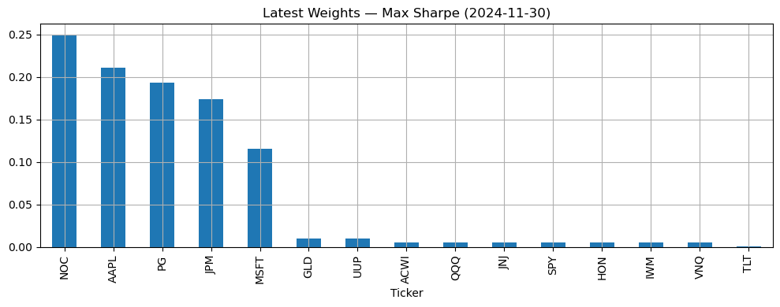

| Ticker | MAX_SHARPE | MIN_VAR | RISK_PARITY | MAX_RETURN |
| --- | --- | --- | --- | --- |
| NOC | 0.250000 | 0.250000 | 0.073089 | 0.250000 |
| AAPL | 0.211041 | 0.011419 | 0.064448 | 0.250000 |
| PG | 0.193641 | 0.173271 | 0.088029 | 0.005000 |
| JPM | 0.174168 | 0.009420 | 0.063436 | 0.250000 |
| MSFT | 0.115149 | 0.080563 | 0.076137 | 0.089971 |
| GLD | 0.010000 | 0.010000 | 0.013456 | 0.010000 |
| UUP | 0.010000 | 0.010000 | 0.013456 | 0.001000 |
| ACWI | 0.005000 | 0.076823 | 0.098149 | 0.005000 |
| QQQ | 0.005000 | 0.042270 | 0.076791 | 0.060079 |
| JNJ | 0.005000 | 0.186343 | 0.102119 | 0.005000 |
| SPY | 0.005000 | 0.063328 | 0.094980 | 0.057949 |
| HON | 0.005000 | 0.026503 | 0.071581 | 0.005000 |
| IWM | 0.005000 | 0.023130 | 0.073558 | 0.005000 |
| VNQ | 0.005000 | 0.026929 | 0.077317 | 0.005000 |
| TLT | 0.001000 | 0.010000 | 0.013456 | 0.001000 |

```python
W_ms = res_ms['weights'].copy(); W_mv = res_mv['weights'].copy(); W_rp = res_rp['weights'].copy(); W_mr = res_mr['weights'].copy()
common_idx = df.index.intersection(W_ms.index)
W_ms = W_ms.loc[common_idx]; W_mv = W_mv.loc[common_idx]; W_rp = W_rp.loc[common_idx]; W_mr = W_mr.loc[common_idx]
latest_date = common_idx[-1]
w_latest = pd.DataFrame({
    'MAX_SHARPE': W_ms.loc[latest_date],
    'MIN_VAR': W_mv.loc[latest_date],
    'RISK_PARITY': W_rp.loc[latest_date],
    'MAX_RETURN': W_mr.loc[latest_date]
}).fillna(0.0).sort_values('MAX_SHARPE', ascending=False)
w_latest.to_csv(f'{OUTDIR}/weights_latest_all_methods.csv')
ax = w_latest['MAX_SHARPE'].sort_values(ascending=False).plot(kind='bar', title=f'Latest Weights — Max Sharpe ({latest_date.date()})'); plt.tight_layout(); plt.show(); w_latest.head(15)
```

## Summary Metrics & Rolling Risk

```python
def summarize_series(ser, bench):
    eq = (1+ser).cumprod(); cagr = ann_ret_fn(ser); vol = ann_vol_fn(ser); shp = sharpe_fn(ser)
    dd, _ = max_drawdown(eq); calmar = np.nan if dd == 0 else cagr/abs(dd)
    a, b = alpha_beta(ser, bench); return {'CAGR': cagr, 'AnnVol': vol, 'Sharpe': shp, 'Alpha(ann)': a, 'Beta': b, 'MaxDD': dd, 'Calmar': calmar}
bench_s = df['BENCH']
summary = pd.DataFrame({c: summarize_series(df[c].dropna(), bench_s) for c in df.columns}).T
summary.to_csv(f'{OUTDIR}/summary_all_series.csv')
summary
```

|  | CAGR | AnnVol | Sharpe | Alpha(ann) | Beta | MaxDD | Calmar |
| --- | --- | --- | --- | --- | --- | --- | --- |
| BENCH | 0.107330 | 0.148044 | 0.724985 | 0.000000 | 1.000000 | -0.507848 | 0.211342 |
| 60_40 | 0.084567 | 0.099161 | 0.852833 | 0.023145 | 0.559726 | -0.284526 | 0.297222 |
| EW_LIVE | 0.131666 | 0.120589 | 1.091857 | 0.044100 | 0.779212 | -0.373061 | 0.352933 |
| MAX_SHARPE_NET | 0.102839 | 0.139172 | 0.738929 | 0.019086 | 0.785103 | -0.515985 | 0.199305 |
| MIN_VAR_NET | 0.076402 | 0.125302 | 0.609744 | -0.002276 | 0.741097 | -0.467915 | 0.163283 |
| RISK_PARITY_NET | 0.102607 | 0.139338 | 0.736385 | 0.004826 | 0.908664 | -0.482056 | 0.212852 |
| MAX_RETURN_NET | 0.125882 | 0.164603 | 0.764763 | 0.026218 | 0.941550 | -0.538888 | 0.233596 |

## Backtesting: Best Strategy vs S&P 500 (Net)

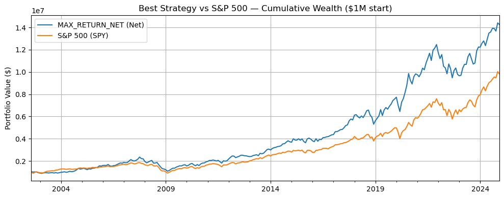

|  | BestStrategy | Net CAGR | Net Sharpe | Alpha(ann) | Beta | AnnVol | MaxDD |
| --- | --- | --- | --- | --- | --- | --- | --- |
| 0 | MAX_RETURN_NET | 0.125882 | 0.764763 | 0.026218 | 0.94155 | 0.164603 | -0.538888 |

```python
cands = df[['MAX_SHARPE_NET','MIN_VAR_NET','RISK_PARITY_NET','MAX_RETURN_NET']]
sranks = cands.apply(sharpe_fn).sort_values(ascending=False)
best_name = sranks.index[0]
# tiebreaker
if sranks.iloc[0] == sranks.iloc[1]:
    cagrs = cands.apply(ann_ret_fn)
    best_name = cagrs.sort_values(ascending=False).index[0]
best = cands[best_name].dropna()
bench = df['BENCH'].reindex(best.index).dropna()
ini = 1_000_000
eq_best = ini*(1+best).cumprod(); eq_bench = ini*(1+bench).cumprod()
fig, ax = plt.subplots(figsize=(10,4))
eq_best.plot(ax=ax, label=f'{best_name} (Net)')
eq_bench.plot(ax=ax, label='S&P 500 (SPY)')
ax.set_title('Best Strategy vs S&P 500 — Cumulative Wealth ($1M start)'); ax.set_ylabel('Portfolio Value ($)'); ax.legend(); plt.tight_layout();
plt.savefig(f'{OUTDIR}/best_vs_sp500_cumulative_wealth.png', dpi=160); plt.show()
metrics = {
    'BestStrategy': best_name,
    'Net CAGR': ann_ret_fn(best),
    'Net Sharpe': sharpe_fn(best),
    'Alpha(ann)': alpha_beta(best, bench)[0],
    'Beta': alpha_beta(best, bench)[1],
    'AnnVol': ann_vol_fn(best),
    'MaxDD': max_drawdown((1+best).cumprod())[0]
}
pd.DataFrame(metrics, index=[0]).to_csv(f'{OUTDIR}/best_vs_sp500_metrics.csv', index=False)
pd.DataFrame(metrics, index=[0])
```

## Efficient Frontier — Analytical & Monte Carlo (Cap-Constrained)

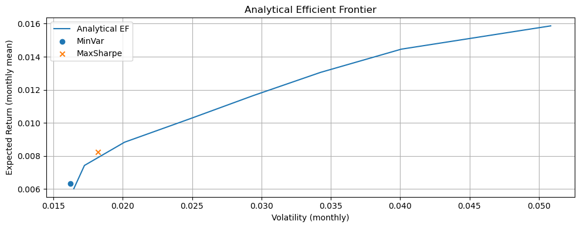

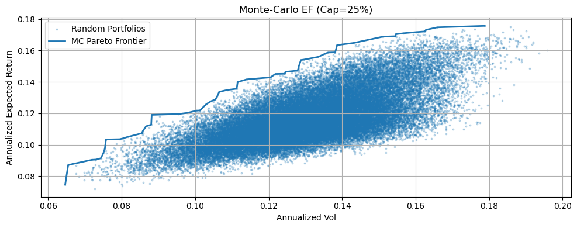

```python
live_mask = avail.any(axis=0); univ = monthly_ret.columns[live_mask]
R = monthly_ret[univ].dropna(how='all'); mu_all = R.mean(); cov_all = R.cov()
def min_var(cov):
    n = cov.shape[0]; x0 = np.ones(n)/n; bounds = [(0, W_MAX)]*n; cons = ({'type':'eq','fun':lambda w: np.sum(w)-1},)
    def var(w): return w @ cov @ w
    res = minimize(var, x0, method='SLSQP', bounds=bounds, constraints=cons)
    return res.x if res.success else x0
w_mv = min_var(cov_all.values); w_ms = solve_max_sharpe(mu_all.values, cov_all.values, wmax=W_MAX)
targets = np.linspace(mu_all.min(), mu_all.max()*1.5, 30); ef_ret, ef_vol = [], []
for tr in targets:
    n = len(mu_all); x0 = np.ones(n)/n; bounds = [(0, W_MAX)]*n
    cons = ({'type':'eq','fun':lambda w: np.sum(w)-1}, {'type':'eq','fun':lambda w, tr=tr: w @ mu_all.values - tr})
    def var(w): return w @ cov_all.values @ w
    res = minimize(var, x0, method='SLSQP', bounds=bounds, constraints=cons)
    if res.success:
        w = res.x; ef_ret.append(w @ mu_all.values); ef_vol.append(np.sqrt(w @ cov_all.values @ w))
fig, ax = plt.subplots(); ax.plot(ef_vol, ef_ret, label='Analytical EF');
ax.scatter(np.sqrt(w_mv @ cov_all.values @ w_mv), w_mv @ mu_all.values, marker='o', label='MinVar');
ax.scatter(np.sqrt(w_ms @ cov_all.values @ w_ms), w_ms @ mu_all.values, marker='x', label='MaxSharpe');
ax.set_xlabel('Volatility (monthly)'); ax.set_ylabel('Expected Return (monthly mean)'); ax.legend(); ax.set_title('Analytical Efficient Frontier'); plt.tight_layout(); plt.show()

rng = np.random.default_rng(SEED)
n = len(mu_all); cap = W_MAX
def sample_weights_with_cap(n, cap, draws):
    out = []
    while len(out) < draws:
        w = rng.dirichlet(np.ones(n))
        if (w <= cap + 1e-12).all():
            out.append(w)
    return np.array(out)
ws = sample_weights_with_cap(n, cap, MC_NUM_SAMPLES)
ann_ret = (ws @ mu_all.values) * 12.0
ann_vol = np.sqrt(np.einsum('ij,jk,ik->i', ws, cov_all.values, ws)) * np.sqrt(12.0)
mc_df = pd.DataFrame({'ann_ret':ann_ret, 'ann_vol':ann_vol})
mc_df.to_csv(f'{OUTDIR}/mc_efficient_frontier_samples.csv', index=False)
mc_df_sorted = mc_df.sort_values('ann_vol'); pareto = []; best=-1e9
for _, row in mc_df_sorted.iterrows():
    if row['ann_ret'] > best + 1e-12:
        pareto.append(row); best = row['ann_ret']
pareto_df = pd.DataFrame(pareto); pareto_df.to_csv(f'{OUTDIR}/mc_efficient_frontier_pareto.csv', index=False)
fig, ax = plt.subplots(); ax.scatter(mc_df['ann_vol'], mc_df['ann_ret'], s=3, alpha=0.25, label='Random Portfolios');
ax.plot(pareto_df['ann_vol'], pareto_df['ann_ret'], lw=2, label='MC Pareto Frontier');
ax.set_xlabel('Annualized Vol'); ax.set_ylabel('Annualized Expected Return'); ax.set_title(f'Monte-Carlo EF (Cap={cap:.0%})'); ax.legend(); plt.tight_layout(); plt.show()
```

## Crisis / Stress Testing — Best Strategy vs SPY

```python
import pandas as pd, numpy as np, matplotlib.pyplot as plt

cands = df[['MAX_SHARPE_NET','MIN_VAR_NET','RISK_PARITY_NET','MAX_RETURN_NET']].dropna()
bench_local = df['BENCH'].reindex(cands.index)
def ann_ret_local(x, periods=12):
    return (1+x).prod()**(periods/len(x)) - 1
def ann_vol_local(x, periods=12):
    return x.std(ddof=0)*np.sqrt(periods)
def sharpe_local(x, rf=0.0, periods=12):
    ex = x - rf/periods
    v = ann_vol_local(ex, periods)
    return np.nan if v==0 else ann_ret_local(ex, periods)/v

sranks = cands.apply(sharpe_local).sort_values(ascending=False)
best_name_local = sranks.index[0]
if len(sranks)>1 and np.isclose(sranks.iloc[0], sranks.iloc[1]):
    cagrs = cands.apply(ann_ret_local)
    best_name_local = cagrs.sort_values(ascending=False).index[0]
best_local = cands[best_name_local]

def period_cagr(series, start, end, periods=12):
    s = series.loc[start:end].dropna()
    if len(s) == 0:
        return np.nan
    return (1+s).prod()**(periods/len(s)) - 1

crises = [
    (pd.Timestamp('2000-03-01'), pd.Timestamp('2002-10-31'), 'Dot-com bust'),
    (pd.Timestamp('2007-10-01'), pd.Timestamp('2009-03-31'), 'GFC'),
    (pd.Timestamp('2020-02-01'), pd.Timestamp('2020-04-30'), 'COVID shock'),
    (pd.Timestamp('2022-01-01'), pd.Timestamp('2022-10-31'), '2022 drawdown')
]
rows = []
for a,b,label in crises:
    rows.append({
        'Period': f"{a.date()}–{b.date()}",
        'Label': label,
        'BestStrategy': best_name_local,
        'CAGR_Best': period_cagr(best_local, a, b),
        'CAGR_SPY': period_cagr(bench_local, a, b)
    })
crisis_tbl = pd.DataFrame(rows)
crisis_tbl.to_csv(f'{OUTDIR}/crisis_cagr_best_vs_spy.csv', index=False)
crisis_tbl
```

|  | Period | Label | BestStrategy | CAGR_Best | CAGR_SPY |
| --- | --- | --- | --- | --- | --- |
| 0 | 2000-03-01–2002-10-31 | Dot-com bust | MAX_RETURN_NET | 0.099473 | -0.094855 |
| 1 | 2007-10-01–2009-03-31 | GFC | MAX_RETURN_NET | -0.342867 | -0.336558 |
| 2 | 2020-02-01–2020-04-30 | COVID shock | MAX_RETURN_NET | -0.214991 | -0.319726 |
| 3 | 2022-01-01–2022-10-31 | 2022 drawdown | MAX_RETURN_NET | -0.220768 | -0.208959 |

We evaluate the **best strategy** (selected by Sharpe, tiebreaker CAGR) across well-known crisis windows.

**Windows**:

- Dot-com bust: 2000-03-01 → 2002-10-31
- Global Financial Crisis (GFC): 2007-10-01 → 2009-03-31
- COVID shock: 2020-02-01 → 2020-04-30
- 2022 equity/bond drawdown: 2022-01-01 → 2022-10-31

Outputs: a **CAGR table** per period and a **cumulative wealth plot** with grey shaded crisis spans.

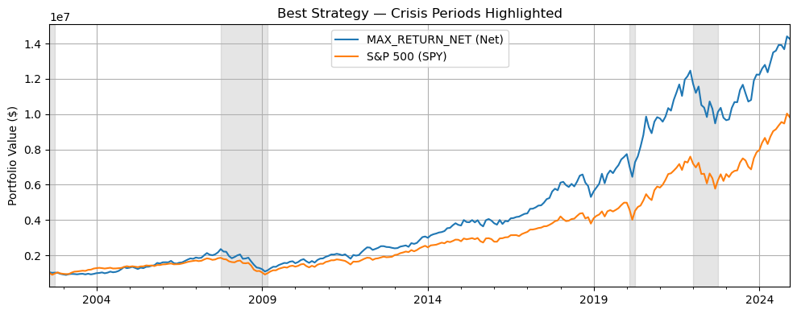

```python
ini = 1_000_000
eq_best_full = ini*(1+best_local).cumprod()
eq_bench_full = ini*(1+bench_local).cumprod()
fig, ax = plt.subplots(figsize=(10,4))
eq_best_full.plot(ax=ax, label=f'{best_name_local} (Net)')
eq_bench_full.plot(ax=ax, label='S&P 500 (SPY)')
for a,b,_ in crises:
    ax.axvspan(a, b, color='grey', alpha=0.2)
ax.set_title('Best Strategy — Crisis Periods Highlighted')
ax.set_ylabel('Portfolio Value ($)')
ax.legend(); plt.tight_layout();
plt.savefig(f'{OUTDIR}/best_strategy_crisis_shaded.png', dpi=160)
plt.show()
```

### Crisis-Period Metrics & Cumulative Dollars Tables

We compute detailed **metrics** for the best strategy vs **SPY** *within each crisis window*, and export the **cumulative dollars** series used in the crisis plot.

**Metrics reported per period**: Months, CAGR, Total Return, Ann. Vol, Sharpe, Max Drawdown, Worst Month, and Terminal Value from a $1,000,000 starting balance.

```python
import numpy as np, pandas as pd
from math import sqrt

cands = df[['MAX_SHARPE_NET','MIN_VAR_NET','RISK_PARITY_NET','MAX_RETURN_NET']].dropna()
def ann_ret(x, periods=12):
    if len(x)==0: return np.nan
    return (1+x).prod()**(periods/len(x)) - 1
def ann_vol(x, periods=12):
    return x.std(ddof=0)*sqrt(periods)
def sharpe(x, rf=0.0, periods=12):
    ex = x - rf/periods; v = ann_vol(ex, periods)
    return np.nan if v==0 else ann_ret(ex, periods)/v
def max_dd_from_returns(x):
    eq = (1+x).cumprod(); peak = eq.cummax(); dd = eq/peak - 1
    return float(dd.min()) if len(dd) else np.nan
def worst_month(x):
    return float(x.min()) if len(x) else np.nan

sranks = cands.apply(sharpe).sort_values(ascending=False)
best_name_local = sranks.index[0]
best_local = cands[best_name_local]
bench_local = df['BENCH'].reindex(best_local.index)

crises = [
    (pd.Timestamp('2000-03-01'), pd.Timestamp('2002-10-31'), 'Dot-com bust'),
    (pd.Timestamp('2007-10-01'), pd.Timestamp('2009-03-31'), 'GFC'),
    (pd.Timestamp('2020-02-01'), pd.Timestamp('2020-04-30'), 'COVID shock'),
    (pd.Timestamp('2022-01-01'), pd.Timestamp('2022-10-31'), '2022 drawdown')
]
ini = 1_000_000
rows = []
for a,b,label in crises:
    s_bst = best_local.loc[a:b].dropna(); s_spy = bench_local.loc[a:b].dropna()
    months = int(len(s_bst))
    eq_bst = ini*(1+s_bst).cumprod()
    eq_spy = ini*(1+s_spy).cumprod()
    rows.append({
        'Label': label,
        'Start': a.date(), 'End': b.date(), 'Months': months,
        'CAGR_Best': ann_ret(s_bst), 'CAGR_SPY': ann_ret(s_spy),
        'TotRet_Best': (1+s_bst).prod()-1, 'TotRet_SPY': (1+s_spy).prod()-1,
        'AnnVol_Best': ann_vol(s_bst), 'AnnVol_SPY': ann_vol(s_spy),
        'Sharpe_Best': sharpe(s_bst), 'Sharpe_SPY': sharpe(s_spy),
        'MaxDD_Best': max_dd_from_returns(s_bst), 'MaxDD_SPY': max_dd_from_returns(s_spy),
        'WorstMo_Best': worst_month(s_bst), 'WorstMo_SPY': worst_month(s_spy),
        'Terminal_Best_$': float(eq_bst.iloc[-1]) if len(eq_bst) else np.nan,
        'Terminal_SPY_$': float(eq_spy.iloc[-1]) if len(eq_spy) else np.nan
    })
crisis_metrics = pd.DataFrame(rows)
crisis_metrics.to_csv(f'{OUTDIR}/crisis_metrics_best_vs_spy.csv', index=False)
crisis_metrics
```

|  | Label | Start | End | Months | CAGR_Best | CAGR_SPY | TotRet_Best | TotRet_SPY | AnnVol_Best | AnnVol_SPY | Sharpe_Best | Sharpe_SPY | MaxDD_Best | MaxDD_SPY | WorstMo_Best | WorstMo_SPY | Terminal_Best_$ | Terminal_SPY_$ |
| --- | --- | --- | --- | --- | --- | --- | --- | --- | --- | --- | --- | --- | --- | --- | --- | --- | --- | --- |
| 0 | Dot-com bust | 2000-03-01 | 2002-10-31 | 3 | 0.099473 | -0.094855 | 0.023991 | -0.024607 | 0.093495 | 0.266292 | 1.063937 | -0.356208 | -0.026425 | -0.104852 | -0.026425 | -0.104852 | 1.023991e+06 | 975392.741135 |
| 1 | GFC | 2007-10-01 | 2009-03-31 | 18 | -0.342867 | -0.336558 | -0.467304 | -0.459613 | 0.235876 | 0.206888 | -1.453590 | -1.626765 | -0.538888 | -0.507848 | -0.118595 | -0.165187 | 5.326963e+05 | 540386.648060 |
| 2 | COVID shock | 2020-02-01 | 2020-04-30 | 3 | -0.214991 | -0.319726 | -0.058720 | -0.091822 | 0.353602 | 0.379503 | -0.608002 | -0.842485 | -0.082620 | -0.124871 | -0.091471 | -0.124871 | 9.412797e+05 | 908177.984161 |
| 3 | 2022 drawdown | 2022-01-01 | 2022-10-31 | 10 | -0.220768 | -0.208959 | -0.187689 | -0.177443 | 0.204296 | 0.224218 | -1.080628 | -0.931947 | -0.191561 | -0.202470 | -0.090829 | -0.092446 | 8.123108e+05 | 822556.876853 |

```python
eq_best_full = ini*(1+best_local).cumprod()
eq_spy_full = ini*(1+bench_local).cumprod()
equity_df = pd.concat([eq_best_full.rename(best_name_local), eq_spy_full.rename('SPY')], axis=1).dropna()
equity_df.to_csv(f'{OUTDIR}/best_vs_spy_equity_full.csv')
equity_df.tail()
```

|  | MAX_RETURN_NET | SPY |
| --- | --- | --- |
| 2024-08-31 | 1.392276e+07 | 9.359372e+06 |
| 2024-09-30 | 1.391301e+07 | 9.555962e+06 |
| 2024-10-31 | 1.367730e+07 | 9.470688e+06 |
| 2024-11-30 | 1.440849e+07 | 1.003546e+07 |
| 2024-12-31 | 1.426594e+07 | 9.829765e+06 |

```python
slices = []
for a,b,label in crises:
    eb = eq_best_full.loc[a:b]; es = eq_spy_full.loc[a:b]
    dfp = pd.concat([eb.rename('Best'), es.rename('SPY')], axis=1)
    dfp['Label'] = label
    slices.append(dfp)
crisis_equity = pd.concat(slices).reset_index().rename(columns={'index':'Date'})
crisis_equity.to_csv(f'{OUTDIR}/best_vs_spy_equity_crisis_slices.csv', index=False)
crisis_equity.head()
```

|  | Date | Best | SPY | Label |
| --- | --- | --- | --- | --- |
| 0 | 2002-08-31 | 1.039387e+06 | 1.006801e+06 | Dot-com bust |
| 1 | 2002-09-30 | 1.011921e+06 | 9.012360e+05 | Dot-com bust |
| 2 | 2002-10-31 | 1.023991e+06 | 9.753927e+05 | Dot-com bust |
| 3 | 2007-10-31 | 2.357020e+06 | 1.862399e+06 | GFC |
| 4 | 2007-11-30 | 2.216644e+06 | 1.790264e+06 | GFC |

## Monte Carlo — Percentile Paths & Ending Balance Histogram (Best Strategy Net)

We bootstrap **monthly net returns** of the **best strategy** to simulate 25-year outcomes.

- Method: **Stationary bootstrap** (random block lengths) to preserve serial dependence.
- Horizon: **25 years** (300 months), Paths: **5,000** (configurable).
- Outputs: (1) **percentile path chart** (5th/25th/50th/75th/95th) and (2) **ending balance histogram** starting from $1,000,000.

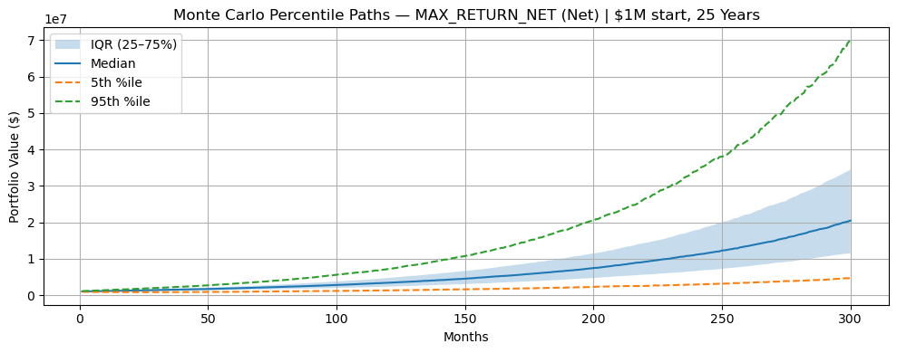

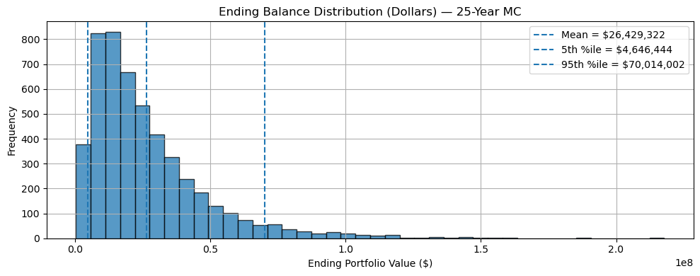

```
Saved figures and tables to: outputs
```

```python
import numpy as np, pandas as pd, matplotlib.pyplot as plt

cands = df[['MAX_SHARPE_NET','MIN_VAR_NET','RISK_PARITY_NET','MAX_RETURN_NET']].dropna()
def _ann_ret(x, periods=12): return (1+x).prod()**(periods/len(x)) - 1
def _ann_vol(x, periods=12): return x.std(ddof=0)*np.sqrt(periods)
def _sharpe(x):
    ex = x
    v = _ann_vol(ex)
    return np.nan if v==0 or np.isnan(v) else _ann_ret(ex)/v
sranks = cands.apply(_sharpe).sort_values(ascending=False)
best_name_plot = sranks.index[0]
best_series = cands[best_name_plot].dropna()

def stationary_bootstrap(series, num_paths=5000, horizon=25*12, block_len=6, seed=202):
    rng = np.random.default_rng(seed)
    arr = series.values; T = len(arr)
    paths = np.empty((num_paths, horizon), dtype=float)
    for i in range(num_paths):
        idx = []
        t = rng.integers(low=0, high=T)
        while len(idx) < horizon:
            run = rng.geometric(1.0/block_len)
            for k in range(run):
                idx.append((t+k) % T)
                if len(idx) >= horizon: break
            t = rng.integers(low=0, high=T)
        paths[i,:] = arr[np.array(idx)]
    return paths

H = 25*12; NUM=5000; BLK=6; INITIAL=1_000_000
mc_returns = stationary_bootstrap(best_series, num_paths=NUM, horizon=H, block_len=BLK, seed=202)
mc_cum_dollars = INITIAL * np.cumprod(1 + mc_returns, axis=1)

p05 = np.percentile(mc_cum_dollars, 5, axis=0)
p25 = np.percentile(mc_cum_dollars, 25, axis=0)
p50 = np.percentile(mc_cum_dollars, 50, axis=0)
p75 = np.percentile(mc_cum_dollars, 75, axis=0)
p95 = np.percentile(mc_cum_dollars, 95, axis=0)
months = np.arange(1, H+1)

fig, ax = plt.subplots(figsize=(10,4))
ax.fill_between(months, p25, p75, alpha=0.25, label='IQR (25–75%)')
ax.plot(months, p50, label='Median')
ax.plot(months, p05, linestyle='--', label='5th %ile')
ax.plot(months, p95, linestyle='--', label='95th %ile')
ax.set_title(f'Monte Carlo Percentile Paths — {best_name_plot} (Net) | $1M start, 25 Years')
ax.set_xlabel('Months'); ax.set_ylabel('Portfolio Value ($)'); ax.legend()
plt.tight_layout(); plt.savefig(f"{OUTDIR}/mc_percentile_paths_dollar_lines_{best_name_plot}.png", dpi=160)
plt.show()

terminals = mc_cum_dollars[:, -1]
mu = terminals.mean(); p5 = np.percentile(terminals, 5); p95 = np.percentile(terminals, 95)
fig, ax = plt.subplots(figsize=(10,4))
ax.hist(terminals, bins=40, alpha=0.75, edgecolor='k')
ax.axvline(mu, linestyle='--', label=f'Mean = ${mu:,.0f}')
ax.axvline(p5, linestyle='--', label=f'5th %ile = ${p5:,.0f}')
ax.axvline(p95, linestyle='--', label=f'95th %ile = ${p95:,.0f}')
ax.set_title('Ending Balance Distribution (Dollars) — 25-Year MC')
ax.set_xlabel('Ending Portfolio Value ($)'); ax.set_ylabel('Frequency'); ax.legend()
plt.tight_layout(); plt.savefig(f"{OUTDIR}/mc_terminal_hist_dollars_{best_name_plot}.png", dpi=160)
plt.show()

mc_dollars = pd.DataFrame({'Month': months, 'p05': p05, 'p25': p25, 'p50': p50, 'p75': p75, 'p95': p95})
mc_dollars.to_csv(f"{OUTDIR}/mc_percentile_paths_dollars_{best_name_plot}.csv", index=False)
pd.DataFrame({'terminal_value': terminals}).to_csv(f"{OUTDIR}/mc_terminal_values_{best_name_plot}.csv", index=False)
print("Saved figures and tables to:", OUTDIR)
```

## Fee Management Scenarios

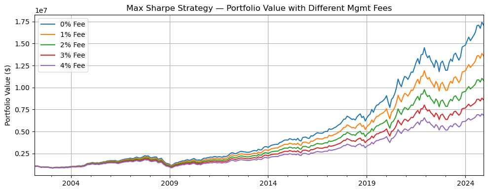

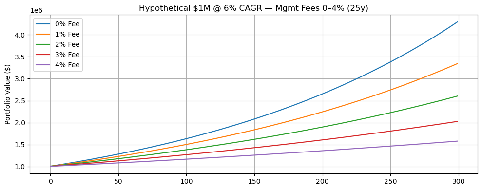

```python
def apply_mgmt_fee_path(gross_monthly, fee_annual, initial=1_000_000):
    fee_m = fee_annual/12.0
    eq = initial
    eq_series = []
    fees_paid = 0.0
    for r in gross_monthly:
        fee_amt = eq * fee_m
        fees_paid += fee_amt
        eq = (eq - fee_amt) * (1.0 + (0.0 if np.isnan(r) else r))
        eq_series.append(eq)
    return np.array(eq_series), fees_paid

gross_series = res_ms['port_gross'].dropna()
fees = [0.00, 0.01, 0.02, 0.03, 0.04]
curves = {}; fee_summary = []
for f in fees:
    curve, paid = apply_mgmt_fee_path(gross_series.values, f)
    curves[f] = pd.Series(curve, index=gross_series.index)
    fee_summary.append({'Fee': f, 'FinalValue': curve[-1], 'FeesPaid': paid})
fee_df = pd.DataFrame(fee_summary)
fee_df.to_csv(f'{OUTDIR}/fee_scenarios_max_sharpe_summary.csv', index=False)
fig, ax = plt.subplots(figsize=(10,4))
for f in fees: curves[f].plot(ax=ax, label=f'{int(f*100)}% Fee')
ax.set_title('Max Sharpe Strategy — Portfolio Value with Different Mgmt Fees'); ax.set_ylabel('Portfolio Value ($)'); ax.legend(); plt.tight_layout(); plt.savefig(f'{OUTDIR}/fee_scenarios_max_sharpe.png', dpi=160); plt.show()

# Hypothetical 6% CAGR example over 25 years
years = 25; months = years*12; r_m = (1+0.06)**(1/12) - 1
curves2 = {}; sum2 = []
for f in fees:
    eq_series, paid = apply_mgmt_fee_path(np.repeat(r_m, months), f)
    curves2[f] = pd.Series(eq_series)
    sum2.append({'Fee': f, 'FinalValue': eq_series[-1], 'FeesPaid': paid})
fee_df_h = pd.DataFrame(sum2)
fee_df_h.to_csv(f'{OUTDIR}/fee_scenarios_hypo6_summary.csv', index=False)
fig, ax = plt.subplots(figsize=(10,4))
for f in curves2: curves2[f].plot(ax=ax, label=f'{int(f*100)}% Fee')
ax.set_title('Hypothetical $1M @ 6% CAGR — Mgmt Fees 0–4% (25y)'); ax.set_ylabel('Portfolio Value ($)'); ax.legend(); plt.tight_layout(); plt.savefig(f'{OUTDIR}/fee_scenarios_hypo6.png', dpi=160); plt.show()
```

## Performance Fee Scenario — 20% over Benchmark Alpha (Annual)

```python
def simulate_with_mgmt_and_perf(gross_ret, bench_ret, mgmt_fee_annual=0.02, perf_rate=0.20, initial=1_000_000):
    gross_ret = pd.Series(gross_ret).dropna(); bench_ret = pd.Series(bench_ret).reindex(gross_ret.index).dropna(); gross_ret = gross_ret.reindex(bench_ret.index)
    fee_m = mgmt_fee_annual/12.0; eq = initial; mgmt_paid = 0.0; perf_paid = 0.0
    cur_year = bench_ret.index[0].year; strat_cum = 1.0; bench_cum = 1.0; equity_path = []
    for dt, r_s, r_b in zip(gross_ret.index, gross_ret.values, bench_ret.values):
        if dt.year != cur_year:
            alpha_return = strat_cum/bench_cum - 1.0
            if alpha_return > 0:
                fee = perf_rate * alpha_return * eq; perf_paid += fee; eq -= fee
            cur_year = dt.year; strat_cum = 1.0; bench_cum = 1.0
        fee_amt = eq * fee_m; mgmt_paid += fee_amt; eq = (eq - fee_amt) * (1.0 + (0.0 if np.isnan(r_s) else r_s))
        strat_net_m = (1.0 - fee_m) * (1.0 + (0.0 if np.isnan(r_s) else r_s)) - 1.0
        strat_cum *= (1.0 + strat_net_m); bench_cum *= (1.0 + (0.0 if np.isnan(r_b) else r_b))
        equity_path.append((dt, eq))
    alpha_return = strat_cum/bench_cum - 1.0
    if alpha_return > 0:
        fee = perf_rate * alpha_return * eq; perf_paid += fee; eq -= fee; equity_path[-1] = (equity_path[-1][0], eq)
    path = pd.Series({d:v for d,v in equity_path}).sort_index(); return path, mgmt_paid, perf_paid

gross_series = res_ms['port_gross'].dropna(); bench_series = df['BENCH'].reindex(gross_series.index).dropna(); gross_series = gross_series.reindex(bench_series.index)
fees = [0.00, 0.01, 0.02, 0.03, 0.04]; rows = []; paths = {}
for f in fees:
    p, mgmt_paid, perf_paid = simulate_with_mgmt_and_perf(gross_series, bench_series, mgmt_fee_annual=f, perf_rate=0.20)
    paths[f] = p; rows.append({'MgmtFee': f, 'FinalValue': p.iloc[-1], 'MgmtFeesPaid': mgmt_paid, 'PerfFeesPaid': perf_paid, 'TotalFees': mgmt_paid + perf_paid})
perf_tbl = pd.DataFrame(rows)[['MgmtFee','FinalValue','MgmtFeesPaid','PerfFeesPaid','TotalFees']]
perf_tbl.to_csv(f'{OUTDIR}/performance_fee_scenarios_20pct_alpha.csv', index=False)
perf_tbl
```

|  | MgmtFee | FinalValue | MgmtFeesPaid | PerfFeesPaid | TotalFees |
| --- | --- | --- | --- | --- | --- |
| 0 | 0.00 | 1.428344e+07 | 0.000000e+00 | 846204.479434 | 8.462045e+05 |
| 1 | 0.01 | 1.178269e+07 | 8.883971e+05 | 631012.267001 | 1.519409e+06 |
| 2 | 0.02 | 9.686721e+06 | 1.551592e+06 | 469418.063932 | 2.021010e+06 |
| 3 | 0.03 | 7.949182e+06 | 2.034832e+06 | 342449.704959 | 2.377282e+06 |
| 4 | 0.04 | 6.504489e+06 | 2.373587e+06 | 245471.535230 | 2.619058e+06 |

## Executive Summary & Exports

```python
print('Saved outputs to', OUTDIR)
display(summary.sort_index().round(4).replace({np.nan: None}).head(20))
```

```
Saved outputs to outputs
```

|  | CAGR | AnnVol | Sharpe | Alpha(ann) | Beta | MaxDD | Calmar |
| --- | --- | --- | --- | --- | --- | --- | --- |
| 60_40 | 0.0846 | 0.0992 | 0.8528 | 0.0231 | 0.5597 | -0.2845 | 0.2972 |
| BENCH | 0.1073 | 0.1480 | 0.7250 | 0.0000 | 1.0000 | -0.5078 | 0.2113 |
| EW_LIVE | 0.1317 | 0.1206 | 1.0919 | 0.0441 | 0.7792 | -0.3731 | 0.3529 |
| MAX_RETURN_NET | 0.1259 | 0.1646 | 0.7648 | 0.0262 | 0.9415 | -0.5389 | 0.2336 |
| MAX_SHARPE_NET | 0.1028 | 0.1392 | 0.7389 | 0.0191 | 0.7851 | -0.5160 | 0.1993 |
| MIN_VAR_NET | 0.0764 | 0.1253 | 0.6097 | -0.0023 | 0.7411 | -0.4679 | 0.1633 |
| RISK_PARITY_NET | 0.1026 | 0.1393 | 0.7364 | 0.0048 | 0.9087 | -0.4821 | 0.2129 |